# Bear River

Sadie Gill, Mark Tompkins

July 2020

## Future Data Improvements

None planned.

## Instream Spawning and Rearing Habitat

**Data Source:** [SSWD 2019](https://cvpiahabitat-r-package.s3-us-west-2.amazonaws.com/cvpia-sit-model-inputs/SSWD_Bear_River_2019.pdf) (pg E3.3.3-78 to 82)

Instream spawning and rearing habitat for Fall Run Chinook Salmon and Steelhead in the Bear River are based on data from an instream flow study conducted by the South Sutter Water District. SSWD performed this study using River2D, a 2-dimensional hydraulic and habitat model. They used this model at two sites to approximate spawning and rearing availability in the Bear River. The U.S. Fish and Wildlife Service collected the same data at a third site, resulting in data for 3 separate reaches. The instream spawning and rearing habitat data were provided to us by Mark Gard from the California Department of Fish and Wildlife. The data were compiled into a spreadsheet. The three reaches were scaled by length and combined. The data were then converted into sqft/1000 ft.

### Spawning and Rearing Data

The instream spawning and juvenile rearing habitat data described above for Fall Run Chinook Salmon (FR) and Steelhead (ST) are combined for use in the Decision Support Model (DSM) in the following format. Units are in square feet per 1000 feet.

Header Descriptions: flow_cfs = flow in cubic feet per second, FR_spawn_wua = Fall Run Chinook Spawning WUA, FR_juv_wua = Fall Run Chinook Juvenile WUA, FR_fry_wua = Fall Run Chinook Fry WUA, ST_spawn_wua = Steelhead Spawning WUA, ST_juv_wua = Steelhead Juvenile WUA, ST_fry_wua = Steelhead Fry WUA, watershed = section of stream modeled for CVPIA SDM

| flow_cfs | FR_spawn_wua | FR_juv_wua | FR_fry_wua | ST_spawn_wua | ST_juv_wua | ST_fry_wua | watershed |
| --- | --- | --- | --- | --- | --- | --- | --- |
| 10 | 392.9599 | 10467.31 | 12237.87 | 210.7500 | 9734.991 | 9393.387 | Bear River |
| 15 | 625.8285 | 10854.46 | 12043.28 | 537.7436 | 10436.479 | 9070.653 | Bear River |
| 20 | 911.5471 | 11073.38 | 11306.65 | 834.7479 | 10919.650 | 8774.826 | Bear River |
| 25 | 1170.8446 | 11201.41 | 11000.88 | 1228.3123 | 11320.709 | 8519.380 | Bear River |
| 30 | 1456.5867 | 11277.72 | 10639.51 | 1569.9535 | 11576.233 | 8230.247 | Bear River |

*…with 15 more rows.*

### Spawning WUA

The following plot shows the weighted usable spawning area (WUA) in square feet per thousand feet for Fall Run Chinook Salmon and Steelhead. These area per length rates are multiplied by the total spawning reach length mapped by the Science Integration Team (SIT) to estimate available habitat.

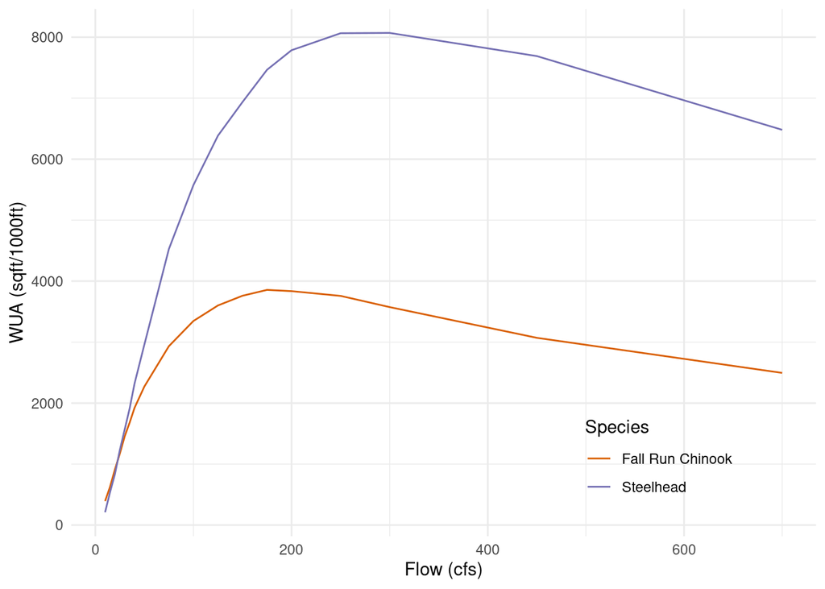

### Rearing WUA

The following plot shows the rearing WUA in square feet per thousand feet for Fall Run Chinook Salmon and Steelhead juvenile and fry. These rates are multiplied by the total rearing reach length mapped by the SIT to estimate available habitat.

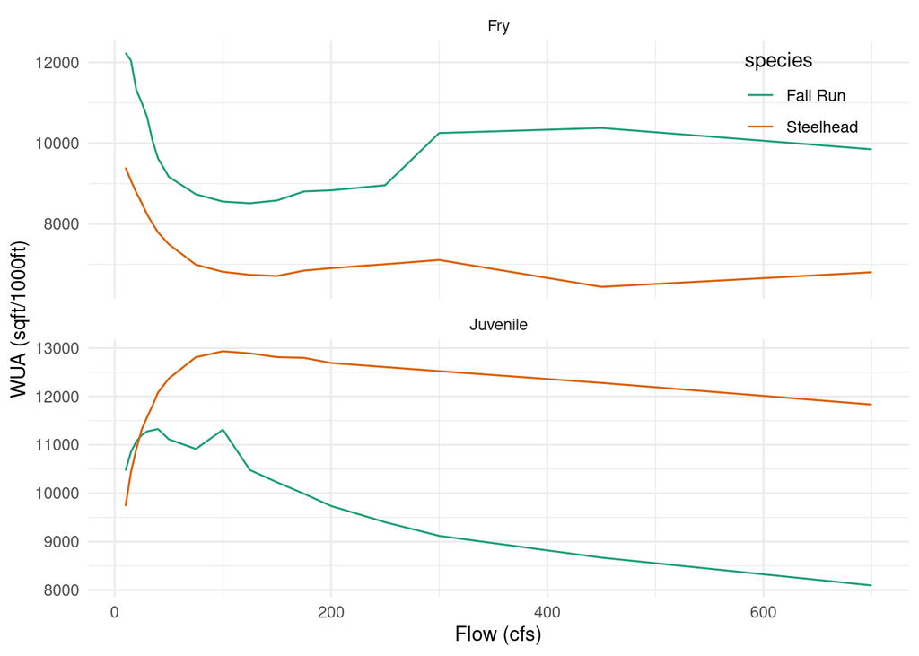

## Floodplain Rearing Habitat

**Data Source:** [Central Valley Floodplain Evaluation and Delineation (CVFED) HEC-RAS hydraulic model](https://s3-us-west-2.amazonaws.com/cvpiahabitat-r-package/cvpia-sit-model-inputs/CombinedTM_IQAR_Final-FULL-REPORT_20140206.pdf)

A 16.4 mile portion of the entire mapped rearing extent of 32.1 miles was modeled using Central Valley Floodplain Evaluation and Delineation (CVFED) HEC-RAS hydraulic model. Of the entire mapped rearing extent, 32 miles were classified as low gradient and 0.1 miles were classified as high gradient based on a geomorphic analysis of long profile slopes and valley widths. The floodplain area per unit length was determined for the modeled extent and used to approximate areas for the non-modeled extent. The area per unit length was scaled by a factor of 0.1 for the high gradient extent. There was no scaling factor applied to the low gradient extent.

## Floodplain Data

The areas represent total inundated area in acres.

Header Descriptions: flow_cfs = flow in cubic feet per second, FR_floodplain_acres = Fall Run Chinook floodplain acres, ST_floodplain_acres = Steelhead floodplain acres, watershed = section of stream modeled for CVPIA SDM

| flow_cfs | FR_floodplain_acres | ST_floodplain_acres | watershed |
| --- | --- | --- | --- |
| 310 | 0.00 | 0.00 | Bear River |
| 460 | 53.99 | 53.99 | Bear River |
| 610 | 93.46 | 93.46 | Bear River |
| 760 | 132.92 | 132.92 | Bear River |
| 910 | 156.45 | 156.45 | Bear River |

*…with 30 more rows*

## Floodplain Plot

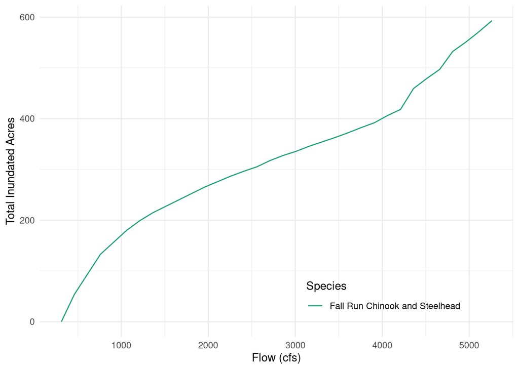